# Supporting Information S2: Vignettes demonstrating the application of the R-package Jsmm

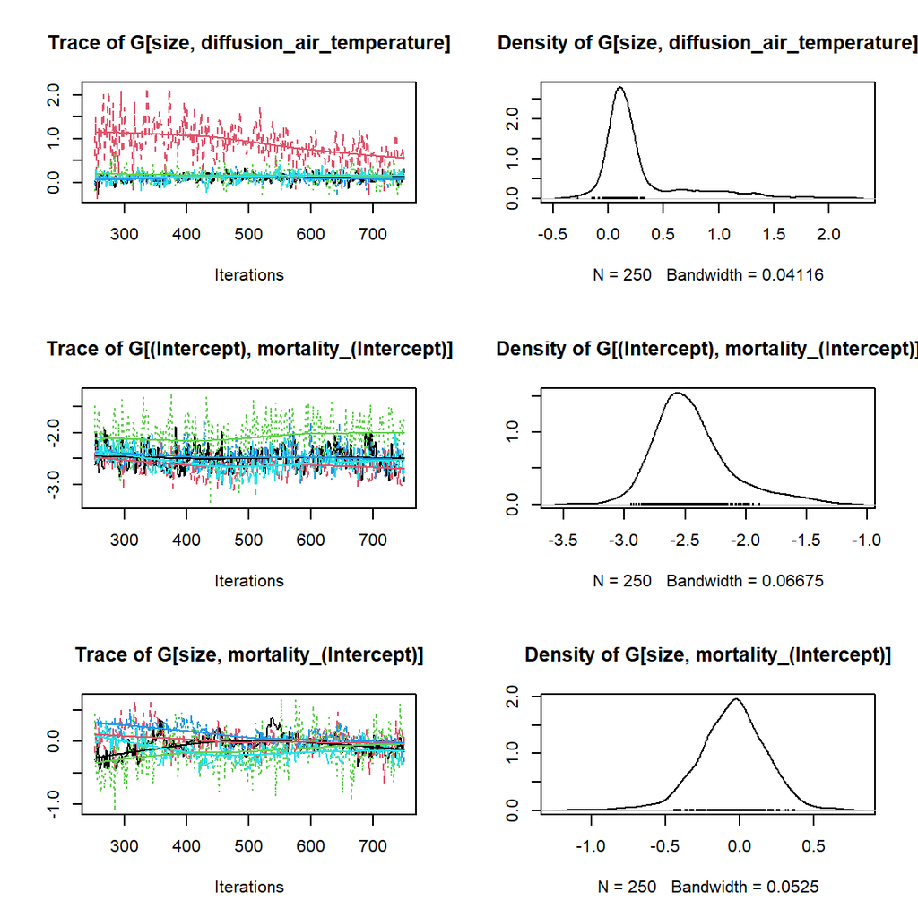

Figure 31: First species trace plots, five MCMC chains Gamma.

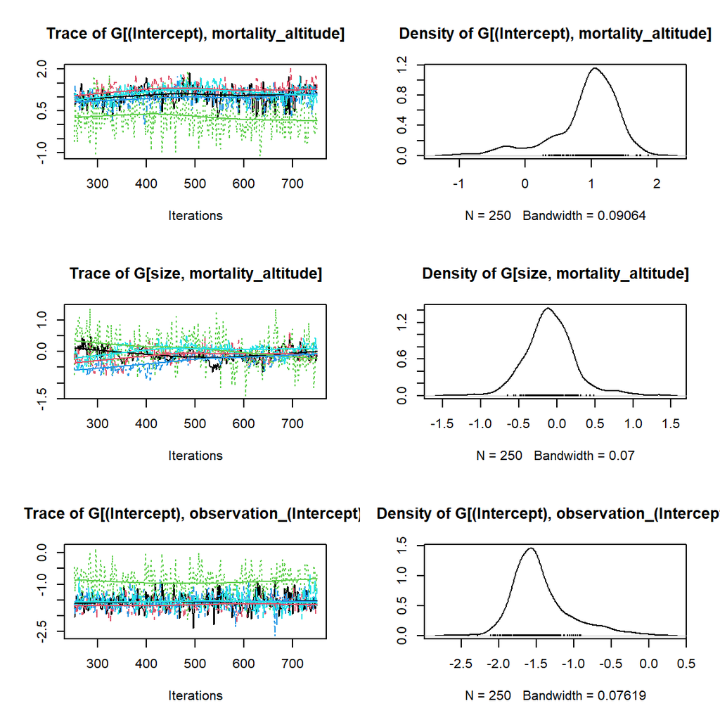

Figure 32: First species trace plots, five MCMC chains Gamma.

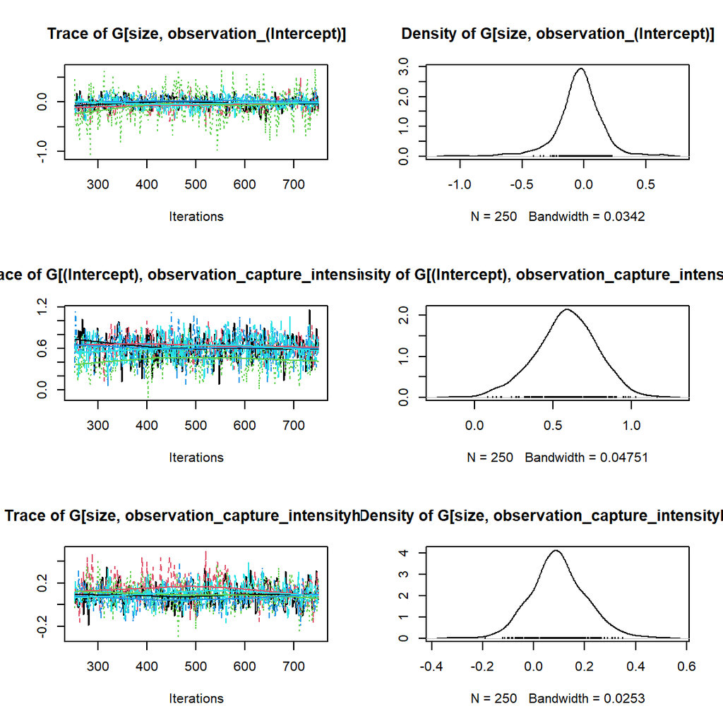

Figure 33: First species trace plots, five MCMC chains Gamma.

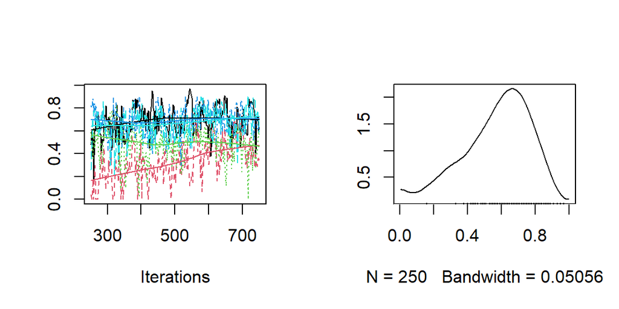

Figure 34: First species trace plots, five MCMC chains Rho.

## Step 2c: Simulate prior and posterior predictive data

The script below generates 1000 datasets for the CCP simulated example. The main purpose of generating predictive data is exploring how the fitted model behaves in time and space compared to the original data. This method helps to infer if the fitted parameters provide a good approximation of the real data.

```r
mname = "simulated_CCP"

for(nrepl in c(1000)){
  showTrueValues = TRUE

  thin    = 2
  samples = 250
  nChains = 5

  load(paste0(paste0("models/fitted_model_", mname, "_samples_", samples, "_thin_", thin,
                     "_nChains_", nChains, ".RData")))

  post = m[["postList"]]

  if(showTrueValues){
    types = c("true", "prior", "posterior")
    load("parameters/true_parameters_CCP.RData")
    true_pars = pars
  }else{
    types =  c("prior", "posterior")
  }

  for(type in types){
    PPcaptures = list()

    for(repl in 1:nrepl){
      if(type == "true"){
        pars = true_pars
      }

      if(type == "posterior"){
        chain = sample(1:length(post), size = 1)
        sa    = sample(1:length(post[[chain]]), size = 1)
        pars  = post[[chain]][[sa]]
      }

      if(type == "prior"){
        pars = Jsmm::simulate_from_prior(m)
      }

      max_dt = NULL
      secondary_release = FALSE
      releases = m[["releases"]]

      m2 = Jsmm::simulate_captures(m = m, pars = pars, releases = releases,
                               max_dt = max_dt, secondary_release = secondary_release)

      captures.simulated = m2[["captures"]]

      if(nrow(captures.simulated) > 0){
        PPcaptures[[repl]] = captures.simulated
      }else{
        PPcaptures[[repl]] = -1
      }
    }
    save(PPcaptures, file = paste0("models/predicted_captures_", mname, "_",
                                   type, "_nrepl_", nrepl, ".RData"))
  }
}
```

## Step 2d: Evaluating model fit

The script below provides a visualization of the posterior predictive data generated on the previous step compared with the original simulated dataset and priors. See Fig. 35.

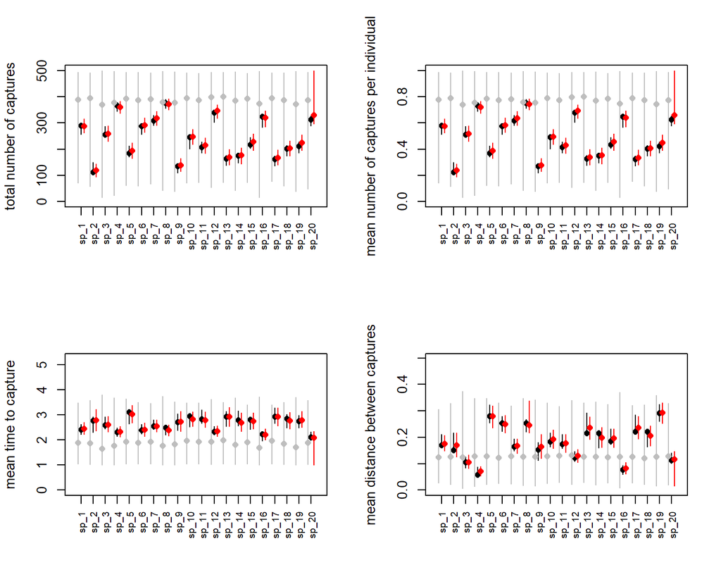

Figure 35: Posterior predictive data generated with 1000 datasets. Black, red, and grey colors represent the datasets generated with true, posterior, and prior parameters values.

```r
showTrueValues = TRUE
showPrior      = TRUE
showPosterior  = TRUE

mname   = "simulated_CCP"
thin    = 2
samples = 250
nChains = 5
nrepl   = 1000

load(paste0(paste0("models/fitted_model_", mname, "_samples_", samples, "_thin_", thin,
                   "_nChains_", nChains, ".RData")))

sel = 1:m$ns

captures = m[["captures"]]

if(showPrior){
  load(file = paste0("models/predicted_captures_", mname, "_prior_nrepl_", nrepl, ".RData"))
  prior.captures = PPcaptures
}

if(showPosterior){
  load(file = paste0("models/predicted_captures_", mname, "_posterior_nrepl_", nrepl, ".RData"))
  posterior.captures = PPcaptures
}

if(showTrueValues){
  load(file = paste0("models/predicted_captures_", mname, "_true_nrepl_", nrepl, ".RData"))
  true.captures = PPcaptures
}

#pdf(paste0("results/model_fit_", mname, ".pdf"))

par(mfrow = c(2, 2))

for(k in 1:4){
  if(k == 1){
    fun  = function(m,captures) Jsmm::number_of_captures(m, captures)
    xlab = ""
    ylab = "total number of captures"
  }

  if(k == 2){
    fun  = function(m,captures) Jsmm::mean_captures(m, captures)
    xlab = ""
    ylab = "mean number of captures per individual"
  }

  if(k == 3){
    fun  = function(m, captures) Jsmm::mean_time_to_capture(m, captures)
    xlab = ""
    ylab = "mean time to capture"
  }

  if(k == 4){
    fun = function(m, captures) Jsmm::mean_distance_between_captures(m, captures)
    xlab = ""
    ylab = "mean distance between captures"
  }

  obs = fun(m, captures)
  ma = max(obs, na.rm = T)

  if(showPrior){
    prior.pred = matrix(ncol = length(obs), nrow = nrepl)
    for(i in 1:nrepl) prior.pred[i, ] = fun(m,prior.captures[[i]])
    ma = max(ma, max(prior.pred, na.rm = TRUE))
  }

  if(showPosterior){
    posterior.pred = matrix(ncol = length(obs), nrow = nrepl)
    for(i in 1:nrepl) posterior.pred[i, ] = fun(m,posterior.captures[[i]])
    ma = max(ma, max(posterior.pred, na.rm = TRUE), na.rm = TRUE)
  }

  if(showTrueValues){
    true.pred = matrix(ncol = length(obs), nrow = nrepl)
    for(i in 1:nrepl) true.pred[i, ] = fun(m, true.captures[[i]])
    ma = max(ma, max(true.pred, na.rm = TRUE))
  }

  plot(obs[sel], ylim = c(0, ma), xlim = c(0.5, m$ns + 0.5), xlab = xlab, ylab = ylab,
       pch = 16, col = "black", cex = 1,
        xaxt = "n")
  axis(1, at = 1:m$ns, label = m$sp_names[sel], las = 2, cex.axis = 0.7)

  if(showTrueValues){
    qu = apply(true.pred, MARGIN = 2, FUN = quantile, prob = c(0.025, 0.975), na.rm = TRUE)
    for(i in 1:length(obs)) lines(x = c(i, i), y = qu[, sel[i]], col = "black")
  }

  if(showPrior){
    qu = apply(prior.pred, MARGIN = 2, FUN = quantile, prob = c(0.025, 0.975), na.rm = TRUE)
    me = apply(prior.pred, MARGIN = 2, FUN = median, na.rm = TRUE)
    points(x = (1:length(me)) - 0.25, y = me[sel], pch = 16, col = "grey")

    for(i in 1:length(obs)) lines(x = c(i, i) - 0.25, y = qu[, sel[i]], col = "grey")
  }

  if(showPosterior){
    qu = apply(posterior.pred, MARGIN = 2, FUN = quantile, prob = c(0.025, 0.975), na.rm = TRUE)
    me = apply(posterior.pred, MARGIN = 2, FUN = median, na.rm = TRUE)
    points(x = (1:length(me)) + 0.25, y = me[sel], pch = 16, col = "red")

    for(i in 1:length(obs)) lines(x = c(i, i) + 0.25, y = qu[, sel[i]], col = "red")
  }
}
```

```r
#dev.off()
```

## Step 3a: Show Posteriors vs priors

The script below provides a visualization of the posterior credible intervals for each model parameter (pink color) and its corresponding prior (grey color). See Fig. 36-38.

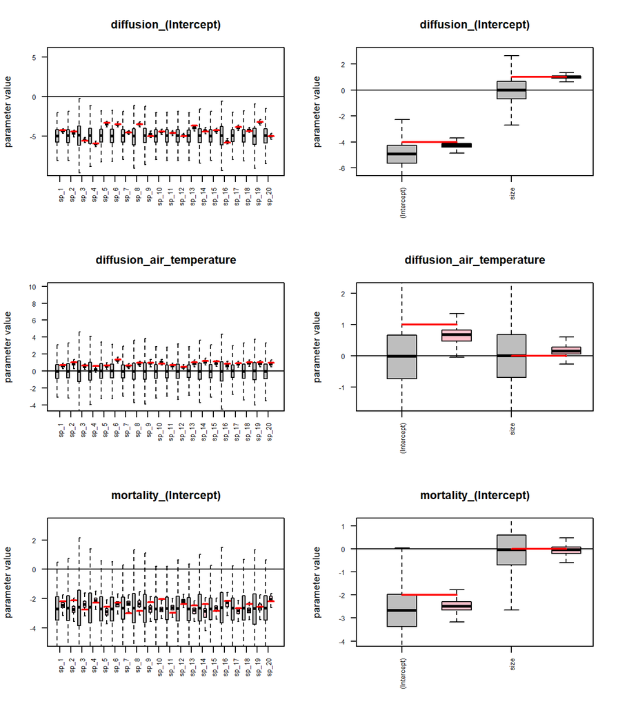

Figure 36: Posterior credible intervals for the model parameters. Left panels show the posteriors for each of the model parameters (pink color), their corresponding priors (Grey), and the parameter true value (Red). Right panels show the corresponding values for the Gamma associated parameter.

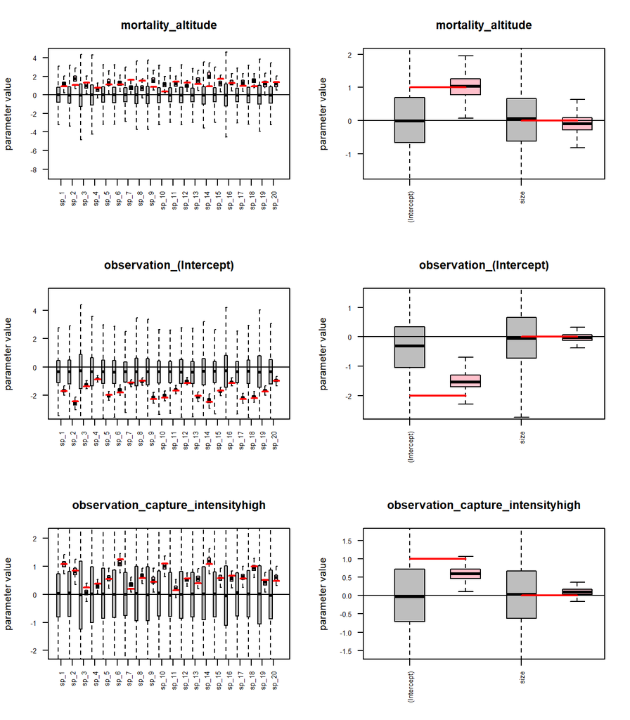

Figure 37: Posterior credible intervals for the model parameters. Left panels show the posteriors for each of the model parameters (pink color), their corresponding priors (Grey), and the parameter true value (Red). Right panels show the corresponding values for the Gamma associated parameter.

[figure not shown]

Figure 38: Posterior credible intervals for the associated rho parameter. Posterior, prior, and true value are represented by pink, grey, and red colors, respectively.

```r
showTrueValues = TRUE
mname = "simulated_CCP"

thin     = 2
samples  = 250
nChains  = 5
filename = paste0(paste0("models/fitted_model_", mname, "_samples_", samples, "_thin_", thin,
                         "_nChains_", nChains, ".RData"))
load(filename)

sel   = 1:m$ns
post  = poolMcmcChains(m[["postList"]])
npost = length(post)
vars  = names(m[["nc"]][m[["nc"]] > 0])
ns    = m[["ns"]]
nt    = m[["nt"]]

nprior = npost
prior  = list()

for(repl in 1:nprior){
  prior[[repl]] = Jsmm::simulate_from_prior(m)
}

load("parameters/true_parameters_CCP.RData")

par(mfrow=c(3,2))

cc = 0
for(va in vars){
  nv = m[["nc"]][[va]]
  for(i in 1:nv){
    cc = cc + 1

    re.pri = matrix(ncol = ns, nrow = nprior)
    re.pri.G = matrix(ncol = nt, nrow = nprior)

    for(repl in 1:nprior){
      re.pri[repl, ]   = prior[[repl]][["Beta"]][[va]][, i]
      re.pri.G[repl, ] = prior[[repl]][["Gamma"]][, cc]
    }

    re.post   = matrix(ncol = ns, nrow = npost)
    re.post.G = matrix(ncol = nt, nrow = nprior)

    for(repl in 1:npost){
      re.post[repl, ]   = post[[repl]][["Beta"]][[va]][, i]
      re.post.G[repl, ] = post[[repl]][["Gamma"]][, cc]
    }

    ymin = min(quantile(re.pri, probs = 0.05), min(re.post))
    ymax = max(quantile(re.pri, probs = 0.95), max(re.post))

    if(showTrueValues){
      ymin = min(ymin, pars$Beta[[va]][, i])
      ymax = max(ymax, pars$Beta[[va]][, i])
    }

    colnames(re.pri) = m$sp_names
    re.pri  = re.pri[, sel]
    re.post = re.post[, sel]

    boxplot(re.pri, outline = FALSE, at = 3*(1:ns)-0.75, ylim = c(ymin, ymax),
            main = m[["parNames"]][cc], las = 2, cex.axis = 0.7,
            xlim = c(2, 3*ns + 2),
            ylab = "parameter value", col = "grey", xaxt = "n")

    axis(1, at = 3*(1:m$ns), label = colnames(re.pri), las = 2, cex.axis = 0.7)

    boxplot(re.post, outline = FALSE, at = 3*(1:ns) + 0.75, col = "pink", add = TRUE,
            xaxt = "n", yaxt = "n")

    abline(h = 0)

    if(showTrueValues){
      for(j in 1:m[["ns"]]){
        lines(x = c(3*j, 3*j + 1.5), y = c(pars$Beta[[va]][j, i], pars$Beta[[va]][j, i]),
              lwd = 2, col = "red")
      }
    }

    ymin = min(quantile(re.pri.G, probs = 0.05), min(re.post.G))
    ymax = max(quantile(re.pri.G, probs = 0.95), max(re.post.G))

    if(showTrueValues){
      ymin = min(ymin, pars$Gamma[, cc])
      ymax = max(ymax, pars$Gamma[, cc])
    }

    colnames(re.pri.G) = colnames(m$X[["trait"]])

    boxplot(re.pri.G, outline = FALSE, at = 3*(1:nt), ylim = c(ymin, ymax),
            main = m[["parNames"]][cc], las = 2, cex.axis = 0.7,
            xlim = c(2, 3*nt + 2),
            ylab = "parameter value", col = "grey")

    boxplot(re.post.G, outline = FALSE, at = 3*(1:nt) + 1.5, col = "pink", add = TRUE,
            xaxt = "n", yaxt = "n")

    abline(h = 0)

    if(showTrueValues){
      for(j in 1:m[["nt"]]){
        lines(x = c(3*j, 3*j + 1.5), y = c(pars$Gamma[j, cc], pars$Gamma[j, cc]),
              lwd = 2, col = "red")
      }
    }
  }
}
```

# How to set temporally varying capture event-specific covariates for CCP capture process

The list **`obs_t_data`** allows temporal variations within capture events. This list has a length equal to the number of capture events. Within each index $c$, there is a data frame (**`obs_t_data[[c]]$cov`**), and a vector (**`obs_t_data[[c]]$times`**) with covariate information and time instants, respectively, for the capture event $c$.

Below we set **`obs_t_data`** for an example in which the domain and observation_effort are as in the Supplementary Material (S 02). We included numeric variables for microclimate and humidity, and factor variables representing the different possible light settings (See Table 1.).

Covariates for the observation parameter

| Covariate name | Event | Time variation within events | Type |
| --- | --- | --- | --- |
| microclimate | No | Yes | Numeric |
| humidity | No | Yes | Numeric |
| light_settings | No | Yes | Factor |

```r
nc = length(observation_effort[["captures"]][["location"]])

obs_t_data = list(list())

for(c in 1:nc){
  t = observation_effort[["captures"]][["time"]][c, ]
  h = sample(1:8, 1)
  ts = seq(from = t[1], to = t[2], by = 1/h)
  li = list()

  li[["covs"]] = data.frame(microclimate = rnorm(length(ts)),
                            humidity = rnorm(length(ts)),
                            light_settings = factor(sample(c("a", "b", "c"), length(ts),
                                                          replace = TRUE) ,
                                                          levels = c("a", "b", "c")))

  li[["times"]] = ts
  obs_t_data[[c]] = li
}
```

```r
cov_data[["obs_t_data"]] = obs_t_data
```

The information for the time-dependent covariate for the capture event $c =$ 35 can be retrieved as

```r
cov_data$obs_t_data[[c]]$covs
```

```
##   microclimate   humidity light_settings
## 1   -1.7872898  0.4376164              b
## 2    0.3413938  0.2702748              a
## 3    2.7339644 -1.6601651              a
## 4    1.1542943  0.1134256              b
## 5   -1.9944199  0.7366299              c
```

```r
cov_data$obs_t_data[[c]]$times
```

```
## [1] 3.00 3.25 3.50 3.75 4.00
```

Note from **`obs_effort$captures`** that the capture event $c =$ 35 occurs on location 8 within the time interval $t_{35,1} =$ 3 and $t_{35,2} =$ 4.

Below is the declaration of the corresponding model formula for the observation parameter:

```r
model_formula[["observation"]] = ~ humidity*microclimate + light_settings

model_formula$observation
```

```
## ~humidity * microclimate + light_settings
```

Note: It is also possible to define formulas as a combination of constant covariates within events and temporally varying within events covariates.

# Summary input data Jsmm software

The function **`jsmm(.)`** that define the model **`m`** object takes as input the following parameters: **`domain`**, **`observation_effort`**, **`releases`**, **`captures`**, **`cov_data`**, **`ns`**,**`sp_names`**, **`C`**, **`tr_data`**, and **`model_formula`**.

## Domain

The input parameter **`domain`** initially is a polygonal object from the class **`sf`**. Each sub polygon within **`domain`** has a label **`id`** that provides information on whether it belongs to a certain habitat and a label **`id_location`** that indicates if it is a release or capture site.

On a second step, **`domain`** is transformed via the function **`domain = jsmm_add_triangulation(.)`** in a named list that consists of two elements. The first element is **`polygon`**, which is a modified polygonal object from the **`sf`** class with triangular polygons defined over $\Omega$ that inherits the labels **`id`**, and **`id_location`** from before.

The second element from the modified **`domain`** is the named list **`triangulation`**, this list consists of the elements **`ele`** and **`node`**. The object **`ele`** is a matrix where the rows correspond to the triangular elements, and the three columns list the nodes that define each element. The object **`node`** is a matrix where the rows correspond to the nodes, and the two columns give the x- and y-coordinates of the nodes.

The function **`jsmm_add_triangulation(domain, max_t_area, min_t_angle)`** has as input the parameters **`max_t_area`**, and **`min_t_angle`**, which provide specifications about area and triangle internal angles constrains for the triangulation. The triangulation within **`jsmm_add_triangulation(.)`** is built based on the triangulation function **`triangulate(.)`** from the R-package RTriangle (Shewchuk (1996)).

## Observation effort

The input parameter **`observation_effort`** object is a named list that describes where and when the releases and captures occur within the experiment. It consists of the objects **`method`**, **`locations`**, **`releases`**, and **`captures`**.

The object **`method`** is a string that describes the nature of the method used for the capture process. Within our framework, the capture process can be defined as instantaneous (**`method = "ICP"`**) or continuous (**`method = "CCP"`**).

The object **`releases`** is a named list that contains the objects **`releases$location`** and **`releases$time`**. This object describes the release events, i.e., the locations and times at which individuals have been released. Both **`location`** and **`time`** are vectors, where each element corresponds to a particular release event. The value of **`location[i]`** describes the release location by giving the relevant index to the list **`observation_effort$locations`**. The value of **`releases$time[i]`** gives the time at which releases took place.

The object **`captures`** is a named list that contains the objects **`captures$location`** and **`captures$time`**. This object describes the capture events, i.e., the locations and times where captures have been attempted. As with **`releases`**, **`location`** is a vector, where each element corresponds to a particular capture event, and its values describe the capture locations by giving the relevant index to the list **`observation_effort$locations`**. In the case of the ICP, **`time`** is a vector, with values indicating the times when the captures were attempted. In the case of the CCP, **`time`** is a matrix, where the rows correspond to the capture events and the two columns show the times when the capture process was started and finished.

## Releases

The object **`releases`** is a matrix that describes the species, locations, and times of the released individuals. The rows of this matrix correspond to the individuals, the first column describes the species, and the second column the release event (which codes the information for location and time).

## Captures

The object **`captures`** contains the capture histories of the individuals (except the release of the individual, which is described in the object **`releases`**). The object **`captures`** is a matrix with three columns, which describe the identity of the individual (index to the row of the matrix **`releases`**), the capture event in which the individual was captured, and a boolean variable describing if the individual was re-released after the capture or not.

## Covariate data

The input parameter **`cov_data`** is a named list that consists of (some combination of) the objects described below.

- *Spatial covariates defined through nodes can be used for diffusion, advection, and mortality*. These covariates are incorporated through a dataframe named **`n_data`**, where the columns correspond to covariates, and the rows correspond to the nodes.
- *Spatial covariates defined through elements can be used for habitat preference, diffusion, advection, and mortality*. These covariates are incorporated through a dataframe named **`e_data`**, where the columns correspond to the covariates, and the rows correspond to the elements.
- *Spatially invariant temporal covariates can be used for diffusion, advection, and mortality.* The values $t_j$ are given in the numeric vector **`t_data_times`**. The values of the covariates are given in the dataframe **`t_data`**, where the columns correspond to the covariates and the rows to the discretization over time.
- *Spatiotemporal covariates defined through nodes can be used for diffusion, advection, and mortality*. The values $t_j$ are given in the numeric vector **`n_t_data_times`**. The values of the covariates are given in the list **`n_t_data`**, where the list element **`n_t_data[[j]]`** corresponds to the time point $t_j$. The object **`n_t_data[[j]]`** is a dataframe, where the columns correspond to the covariates and the rows to the nodes.
- *Spatiotemporal covariates defined through elements can be used for habitat preference, diffusion, advection, and mortality.* The values $t_j$ are given in the numeric vector **`e_t_data_times`**. The values of the covariates are given in the list **`e_t_data`**, where the list element **`e_t_data[[j]]`** corresponds to the time point $t_j$. The object **`e_t_data[[j]]`** is a dataframe, where the columns correspond to the covariates and the rows to the elements.
- *Capture event-specific covariates can be used for ICP and CCP.* These covariates are incorporated through a dataframe named **`obs_data`**, where the columns correspond to the covariates, and the rows correspond to the capture events.
- *Temporally varying capture event-specific covariates can be used for CCP.* These covariates are incorporated through a list named **`obs_t_data`**, where each list element **`c`** corresponds to a particular capture event. For event $c$, the values $t_j$ are given in the numeric vector **`obs_t_data[[c]]$times`**. The values of the covariates are given in the dataframe **`obs_t_data[[c]]$covs`**, where the columns correspond to the covariates and the rows to the discretization over time.

## Model formula

The input parameter **`model_formula`** is a named list that consists of (some combination of) the objects **`diffusion`**, **`advection`**, **`mortality`**, **`habitat_preference`**, **`observation`**, and **`traits`**. These follow the R-notation for model formulae, e.g., **`model_formula$diffusion =`** $\sim$ **`habitat*temperature`**, if diffusion is assumed to depend on habitat type, temperature, and their interaction. The intercept is included in all other model formulas except for **`habitat_preference`**, as adding an intercept to habitat preference would overparameterize the model. The user does not need to include $\sim -1$ in the model of habitat preference as the intercept is removed automatically.

- The model formulae for **`diffusion`**, **`advection`**, **`mortality`** and **`habitat_preference`** can involve any variables that are included in the objects **`n_data`**, **`e_data`**, **`t_data`**, **`n_t_data`** or **`e_t_data`**.
- The model formula for **`observation`** can involve any variables that are included in the objects **`obs_data`** (for both ICP and CCP) or **`obs_t_data`** (for CCP only).
- The model formula for **`traits`** can involve any variables that are included in the objects **`tr_data`**.

## Number of species

The integer **`ns`** is the number of species included in the model.

## Species names

The string vector **`sp_names`** is an optional parameter assigning the species names.

## Trait and phylogenetic data

The trait data is characterized within the **`tr_data`** dataframe component. The columns correspond to the covariates, and the rows to the number of species.

The matrix **`C`** includes the phylogenetic relationships among the species.

# References

Pebesma, Edzer. 2018. “Simple Features for R: Standardized Support for Spatial Vector Data.” *The R Journal* 10 (1): 439–46. https://doi.org/10.32614/RJ-2018-009.

Pebesma, Edzer, and Roger Bivand. 2023. *Spatial Data Science: With applications in R*. Chapman and Hall/CRC. https://doi.org/10.1201/9780429459016.

Plummer, Martyn, Nicky Best, Kate Cowles, and Karen Vines. 2006. “CODA: Convergence Diagnosis and Output Analysis for MCMC.” *R News* 6 (1): 7–11. https://journal.r-project.org/archive/.

Shewchuk, Jonathan Richard. 1996. “Triangle: Engineering a 2D Quality Mesh Generator and Delaunay Triangulator.” In *Applied Computational Geometry: Towards Geometric Engineering*, edited by Ming C. Lin and Dinesh Manocha, 1148:203–22. Lecture Notes in Computer Science. Springer-Verlag.